# Procedurally Generated Congressional Districts

Results and Findings for Ohio’s 2020 Congressional Elections

Tim Ballesteros

2025-05-19

## Introduction

The United States House of Representatives is composed of 435 voting members, each elected from a single-representative first-past-the-post district. The number of districts a state receives is proportional to its population, with the process of reapportionment recalculating the number of representatives each state receives based on the decennial census. Updated populations from the census also require updating the borders of districts to account for population changes over the last decade. Districts for the House of Representatives under these new number of districts and population counts are first used two years after the fielding of the decennial census.

For a majority of states, the state must split up its territory into two or more congressional districts. District requirements vary by state, but across all states must be contiguous and all districts in the state must have equal populations. Building off census tracts, an innumerable combination of congressional districts arise even in states like Idaho or Maine, each of which currently have just two congressional districts each. State governments set its own methods for creating district maps; the methods can emphasize certain aspects, such as requirements for majority-minority districts. Overall, however, the main division to emerge in recent decades is between maps drawn by politically-neutral or politically-balanced committees and those drawn by partisan elected officials.

Ohio, a state until recently dubbed a bellwether state for presidential elections, has been one of a handful of states to receive heightened scrutiny for its redistricting practices.[^1]

## Methodology

### Map Generation

**Requirements.** While the redistricting process is generally left for each state to determine, elections for federal positions have universal requirements. Additionally, specific rules for congressional districts exist, as these are not statewide elections like senetorial or presidential races. Federal requirements include:[^2]

1. *Population Equity*: Within each state, districts must be drawn to approximately equal size populations. District populations may vary across states, however.
2. *Minority Protections*: Under the Voting Rights Act of 1965, “[n]o voting qualification … shall be imposed or applied by any State or political subdivision to deny or abridge the right of any citizen of the United States to vote on account of race or color.”[^3] This prevents states from drawing district maps that reduce or dilute (minority) racial or ethnic groups.

States often impose additional requirements via their state constitution or through legislative bills. Common requirements include compactness, contiguousness, and preservation of existing subdivisions (e.g., counties or cities). Specifically, Ohio has the following additional requirements:

3. *Compactness*
4. *Contiguous*
5. *Political Subdivision*
6. *Communities of Interest*

The Ohio state legislature is the primary redistricting authority for federal congressional maps. A majority of states have legislature-dominant redistricting methods, though a handful of states utilize commissions or hybrid methods. Beginning in the 2020 redistricting cycle (i.e., applying starting with the 2022 elections) following a 2018 constitutional amendment expands the process and approval steps required to enact a new map, including allowing for the governor to veto the map. Additionally, the law stipulates limitations on dividing counties: 65 counties cannot be divided, 18 can be split between only two districts each, and the five largest counties only amongst three districts.[^4]

**Operationalization.** For purposes of this study, several of these requirements are laxed or removed. Equal population requirements, while still being required in this study, are focused on as a measurement of fairness, instead of being a starting point. As Ohio’s 2020 constitutional amendment did not cover the 2020 election’s congressional districts, rules regarding limits on dividing counties are ignored.

**Procedural Generation.** Congressional district maps for Ohio are procedurally generated, using only United States Census total population counts and geographical information (e.g., tract adjacency). Additional demographic information, namely race and ethnicity data, is intentionally excluded from this study. While using this data is legal - indeed, even required - in some states to ensure majority-minority district requirements are fulfilled, one of my goals is to assess whether the created districts show notable bias against particular groups. Without the inclusion of race and ethnicity, is there potential for an algorithmic approach to district creation to dilute non-white non-Hispanic groups’ electoral power? Ohio has only limited ability to test this, with the state being overwhelmingly white, non-Hispanic. Substantial concentrations of other groups, particularly Black, non-Hispanic communities, exist in and around several large cities such as Cleveland, Akron, and Columbus. However, in the case of Ohio, this largely amounts to testing whether and how an algorithm might break up urban areas.

During the 2020 election, Ohio had 16 congressional seats. Leveraging this count as a power of two, my algorithm splits an area into two areas with equal populations; recursively executing this process results in 16 districts. The following steps are conducted to split a geography in two:

1. Filter out the six unpopulated census tracts containing only water in Lake Erie. Filter out enclave census tract(s) from the data and merge their populations with the surrounding census tract. This ensures the enclave tract will always be in the same district as the surrounding tract.
2. Randomly select two census tracts ($tract_{1}$ and $tract_{2}$) from the population of tracts.
3. For each census tract in the population, calculate the distance (the minimum number of tracts needed to cross to reach one tract from another) to both random tracts $tract_{1}$ and $tract_{2}$ ($dist_{1}$ and $dist_{2}$).
4. Calculate the relative distance from each census tract to $tract_{1}$ and $tract_{2}$, defined as the difference of distances $dist_{r} = dist_{2} - dist_{1}$.
5. Identify the most extreme relative distances (i.e., the highest and lowest $dist_{r}$): $d_{-}$ and $d_{+}$. Identify all census tracts with these respective values, where $\mathbf A$ is the group of tracts with $dist_{r} == d_{-}$ and $\mathbf B$ is the group where $dist_{r} == d_{+}$. For each group, assess whether the group contains only one tract. If the group contains multiple tracts, assess whether all tracts are contiguous. If the tracts are discontiguous, determine the group with the largest count of contiguous tracts and remove all other tracts from the group.
6. Calculate the populations of $\mathbf A$ and $\mathbf B$. Additionally, calculate the target population for the districts, defined as $\frac{\sum x}{2} - \hat{x}$, where $x$ is the census tract population and $\hat{x}$ is the median tract population. As the cutoff population is calculated after a census tract’s population is added, this factors in the addition of the population causing the district to exceed the population cutoff value. The population target will vary depending on the composition of the tract population. In the inital step of dividing Ohio into two districts, the population target is 49.968%.
7. Expand $\mathbf A$ and $\mathbf B$ by incorporating adjacent census tracts with values of $d_{-}+1$ and $d_{+}-1$, respectively.
8. Repeat this process, recalculating adjacent census tracts and the populations of $\mathbf A$ and $\mathbf B$ after each step, until the population of either $\mathbf A$ or $\mathbf B$ surpasses the target population.
9. Assign all census tracts in the population not assigned to $\mathbf A$ or $\mathbf B$ to the set with the smaller population.
10. Calculate continuity of $\mathbf A$ and $\mathbf B$. Reassign any tracts disconnected from the contiguous group with the largest count of districts to the other set $\mathbf B$ or $\mathbf A$.
11. While the populations of $\mathbf A$ or $\mathbf B$ are less than the population goal, reassign census tracts from the smaller district $\mathbf X$ that border the largest district $\mathbf Y$ starting with those with the largest percentage of adjacent tracts belonging to $\mathbf Y$.
12. Iterate through the previous two steps until both $\mathbf A$ and $\mathbf B$ are contiguous and have populations above the population target.
13. Reincorporate enclave census tracts by assigning them the district of the surrounding tract.

The result will be two districts with roughly even populations between $\frac{\sum x}{2} - \hat{x}$ and $\frac{\sum x}{2} + \hat{x}$. The process is repeated using these new districts as the starting populations of subsequent splits until a total of 16 districts are created. The process through to this result is referred to as a “run” and the resulting assignment of all census tracts into one of 16 districts is called a “map.”

Below are visualization of key steps in the above process.

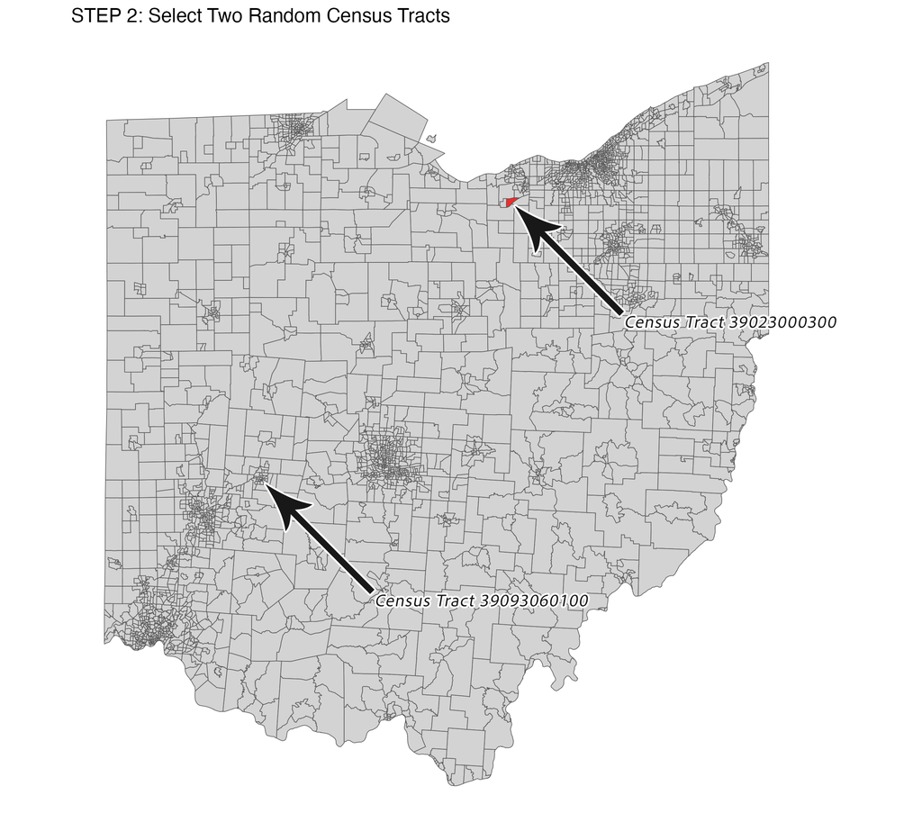

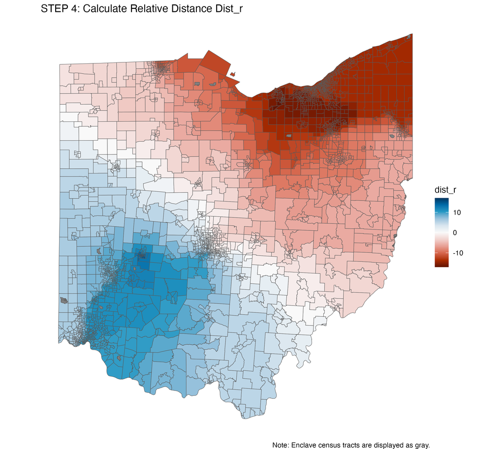

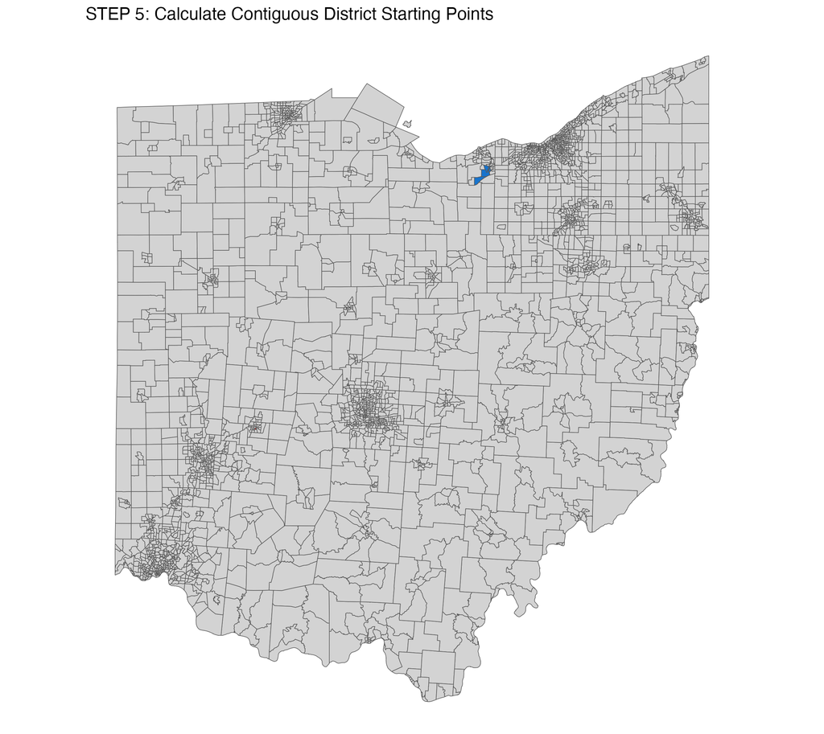

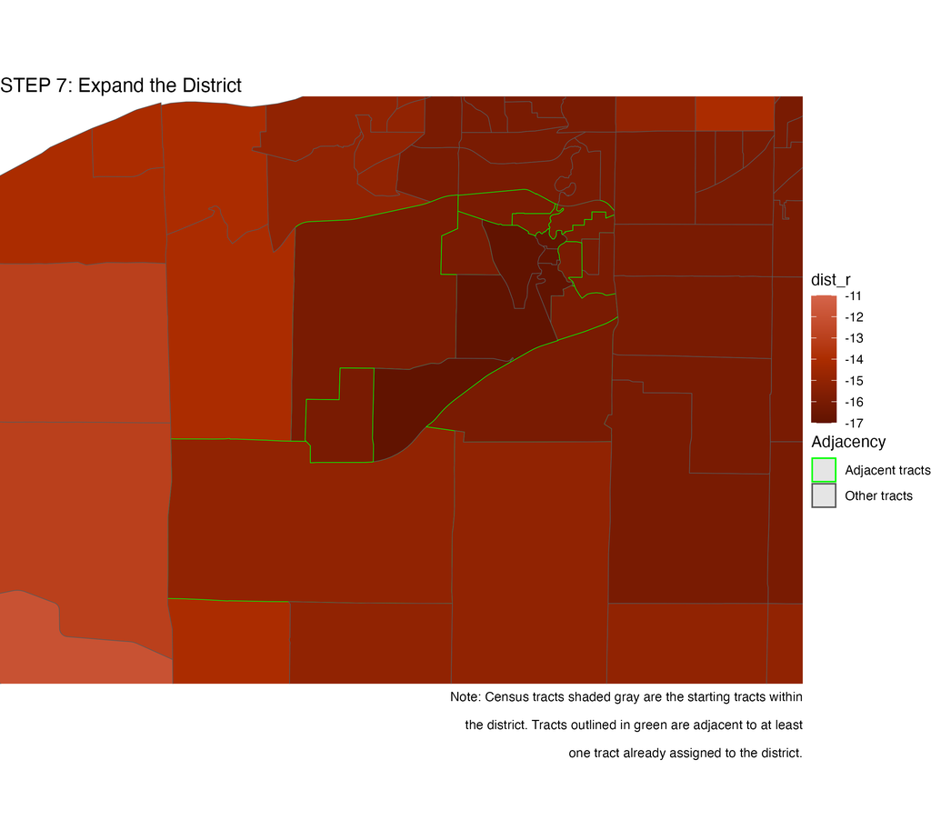

### Map Comparison

To test whether an algorithm randomly constructing congressional districts within the typical confines - contiguous, equal populations - I use Ohio as an example. Using the post-2010 United States Census redistricting, population data from 2010 is used in conjunction with Ohio’s 2020 election results, which use districts based on the 2010 Census. Results will be compared across four aspects, with multiple specific metrics compared within these aspects:

1. **Partisanship**: Assessing district competitiveness and how many seats each map produces for each candidate compared to the 113th Congress’s actual seat allocation and the number of votes each party received state-wide.
- *Allocation District Seats Won*
- *Absolute District Competitiveness*, not taking party leaning into consideration, only using the scale of the win margin.
- *Relative District Competitiveness*, taking party leaning into consideration in addition to the scale of the win margin.
2. **Population**: Verifying whether the maps fulfill equal population requirements and comparing to the 113th Congress’s district populations.
3. **Race/Ethnicity**: Assessing racial and ethnic group distribution across the districts and compared to districts for the 113th Congress’s racial and ethnic spread.
- *Diversity Index*
- *White % vs Non-White %*
4. **District Compactness**: Utilizing several operationalisations of district compactness.

**Partisanship.** To compare partisanship with the actual results, the *Allocation of Seats Won*, the *Absolute District Competitiveness*, and the *Relative District Competitiveness* are compared against the 2020 election results. Using RDH’s estimated 2020 election results redistributed by census tract, the number of votes within the 2020 presidential election are used as a proxy for congressional voting intention.

To calculate the *Allocation of Seats Won*, the party to receive the most votes in the newly created district is selected as the winner. Third-party votes remain in the calculations, so the winner need not win a majority of the votes, only a plurality. This is the same method used in actual results for a majority of federal, state, and local elections. The number of wins are summed across the 16 districts.

To calculate a comparable real-world counter, the actual seat allocation for the 117th Congress ($S_{R1}$ and $S_{D1}$ for the number of seats won by Republicans and Democrats, respectively) is used alongside two theoretical metrics, both of which calculate seat apportionment at a state-wide level using a proportional representation (PR) multi-member district election system, with seats distributed using the Sainte-Laguë method. These results apply Ohioans’ votes proportionally, such that the ratio of votes for each party matches the ratio of congressional seats allotted to that party.

The first calculation ($S_{R2}$ and $S_{D2}$) uses the 2020 presidential election results, which will distribute seats in line with the proportions of votes cast for each candidate in the presidential election - 53.3% for Trump and 45.2% for Biden. By using the presidential race results, voters across the state are voting for the same race with the same candidates, removing possible impacts of candidate-specific differences possible when using votes for different congressional candidates. This method does assume voters generally vote party-line tickets, where the voter votes for candidates of the same party for partisan elections.

As a counter to this, the second theoretical metric ($S_{R3}$ and $S_{D3}$) uses 2020 congressional election results. This better measures the results of the actual elections the model is attempting to assess. The method also allows for split-ticket voting; individuals may vote differently for a presidential candidate - a heavily nationalized race - versus a congressional candidate - historically more tied to local issues. However, individual candidates differ across the state and individual candidate popularity could draw different voting results even across similar districts.

In the case of the 2020 election in Ohio, both theoretical metrics result in the same seat allocation: 9 seats for Republicans and 7 seats for Democrats ($S_{R2}$ = $S_{R3}$ = 9 and $S_{D2}$ = $S_{D3}$ = 7). Ohio’s 2020 election saw 12 Republicans ($S_{D1} = 12$) and 4 Democrats ($S_{D1} = 12$) winning seats for the 117th Congress.

*Absolute District Competitiveness* and *Relative District Competitiveness* both measure by what margin the winning candidate wins the district by.

The *Absolute Win Margin* ($w_{abs}$) is calculated as the absolute value of the difference in the two-party percentage, such that the winner being a Democrat or Republican is not factored into the value. This excludes any third-party or write-in votes. $w_{abs} = |\frac{votes_{d}}{votes_{d} + votes_{r}} - \frac{votes_{r}}{votes_{d} + votes_{r}}|$, where $w_{abs}$ is the absolute win margin of a district and $votes_{d}$ and $votes_{r}$ are the count of votes for the Democratic and Republican candidates, respectively. This can be simplified to $w_{abs} = \frac{|votes_{d} - votes_{r}|}{votes_{d} + votes_{r}}$. The values are confined between 0 and 100, with 0 representing an exactly even split of votes between the Democrat and Republican and 100 representing one of the candidate receiving every vote while the other candidate receives none.

The *Relative Win Margin* ($w_{rel}$) is calculated as the directed value of the difference in the two-party percentage, such that positive or negative values indicate a Democrat or Republican won more votes, respectively. Once again, this excludes any third-party or write-in votes. $w_{rel} = \frac{votes_{d}}{votes_{d} + votes_{r}} - \frac{votes_{r}}{votes_{d} + votes_{r}}$, which simplifies to $w_{rel} = \frac{votes_{d} - votes_{r}}{votes_{d} + votes_{r}}$, where $w_{rel}$ is the absolute win margin of a district and $votes_{d}$ and $votes_{r}$ are the count of votes for the Democratic and Republican candidates, respectively. The values are confined between -100 and 100, with -100 indicating a Republican won all the two-party votes, a 0 indicating the Democrat and Republican won equal number of votes, and a 100 indicating a Democrat won all the two-party votes. The absolute value of this metric is the absolute win margin $w_{abs}$. This value is akin to a Cook Political Score value or other similar district partisan measurements.

Both these metrics emulate district leaning metrics such as the Cook Political Score, with $w_{abs}$ ignoring which party the lean is towards and $w_{rel}$ including it. These metrics are used to represent how competitive a given district is, with very low values (or values closer to 0) indicating a toss-up. Higher values (or values further from 0) indicate more partisan districts (i.e., “solid Republican” or “safe Democrat”).

For purposes of comparing these partisan metrics to actual and theoretical results, distributions of seats closer to proportional representation and more competitive districts are seen as a better outcome. While normative, these have support in theoretical and empirical election research.

**Population.** District population results are compared to the actual district populations and the actual equal population distribution. For each map, the median, minimum, and maximum district populations are compared to the same summary values of districts in the 117th Congress. These values are additionally compared to $P_{16} =$ 721,032, one-sixteenth of Ohio’s population as tabulated in the 2010 Census.

**Race and Ethnicity.** Multiple metrics are used to determine the racial and ethnic composition - ethnic here referring to Hispanic or non-Hispanic. This is done to determine if the procedurally generated maps are incorporating racial bias (either in violation of state or federal law or otherwise biased). Two key metrics are used: the *Diversity Index* and the *White-to-Nonwhite Margin*. Populations are grouped across eight common racial and ethnic categories, as derived from Census data: White, non-Hispanic; Black, non-Hispanic; Hispanic of any race; Asian, non-Hispanic; Native Hawaiian or Pacific Islander (NHPI), non-Hispanic; American Indian or Alaskan Native (AIAN), non-Hispanic; other race, non-Hispanic; and two or more races.

The *Diversity Index* is a commonly used measurement calculating the racial/ethnic diversity within a given area, including use by the United States Census Bureau.[^5] Specifically here, the Gini-Simpson index is used, defined as $D = 1 - \sum_{}^{} \rho_{i}^{2}$, where $\rho_{i}$ is the proportion of the population belonging to each of the eight race/ethnicity groupings. This value corresponds with the probability that any two individuals drawn from the population at random will be of different race/ethnic groups. A higher index score indicates greater diversity; for a calculation with eight groups, the highest possible score is 0.875. A score of 0 indicates the entire population belongs to the same race/ethnic group. The state-wide Diversity Index score for Ohio based on the 2010 Census is $D_{OH} =$ 0.326.

Similarly, the *White-to-Nonwhite Margin* measures the racial/ethnic diversity of a population considering only two groups: White, non-Hispanic and non-White (including White, Hispanic). This metric is calculated as $W = \rho_{w} - \sum_{}^{} \rho_{j}$, where $\rho_{w}$ is the proportion of White, non-Hispanic individuals in the population and $\rho_{j}$ are the proportions of all the other racial/ethnic groups. This can be rewritten as $W = 2\rho_{w} - 1$, as all individuals are assigned to one of the eight groups. The Ohio-wide White-to-Nonwhite Margin is $W_{OH} =$ 0.623. This corresponds to a 81.1% White, Non-Hispanic population and a 18.9% non-White population.

**District Compactness.** Several calculations of district compactness are used, with all measuring how geographically concentrated the district is. The more round a district is (i.e., minimizing the distance of each census tract from the center of the district), the more compact a district is. Specific measurements operationalise this differently.

The *Polsby-Popper* (PP) compactness score is the ratio of the district’s area ($A_{D}$) to the area of a circle whose circumference is equal to the perimeter of the district: $C_{PP} = 4\pi\frac{A_{D}}{P^{2}_{D}}$, with $P_{D}$ being the perimeter of the district. The scores range 0 to 1, with a higher score indicating greater compactness.

The *Schwartzberg* compactness score is the ratio of the circumference of a circle whose area is equal to the area of the district to the perimeter of the district ($P_{D}$): $C_{S} = \frac{2\pi\sqrt{A_{D}/\pi}}{P_{D}}$, where $A_{D}$ is the area of the district. This score also ranges from 0 to 1, with a higher score indicating a more compact district.

A third measure of compactness, the *Reock* compactness score, is the ratio of the area of a district ($A_{D}$) to the area of the minimum bounding circle ($A_{MBC}$) that encloses the district: $C_{R} = \frac{A_{D}}{A_{MBC}}$. The score ranges from 0 to 1, with a score closer to 1 indicating a more compact district.

Below shows the three different methodologies applied to Ohio’s 3rd Congressional District, centered around Columbus. The compactness scores for this district are $C_{PP,03} =$ 0.056, $C_{S,03} =$ 0.238, $C_{R,03} =$ 0.457.

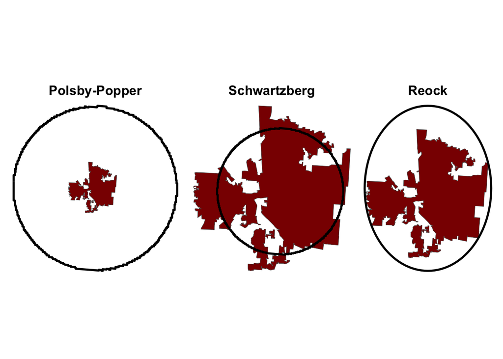

## Findings

### Partisanship

**Allocation of Seats Won.** Across the 70 procedurally generated congressional maps of Ohio’s 16 seats using 2010 Census data, the most frequent number of seats won by Republicans was 11 and won by Democrats was 5. The mean values for Republicans and Democrats were $\overline{x}_{R} =$ 10.9 and $\overline{x}_{D} =$ 5.1 with standard distributions of $\sigma =$ 0.887. The results range from 9 to 13 seats for Republicans and 3 to 7 for Democrats.

Table 1 shows the frequencies for each number of seats won by party per procedurally generated map. Values for the actual 117th Congress seat allocation $S_{R1} = 12$ and $S_{D1} = 4$ are shown as black dashed lines, while the theoretical PR seat allocations $S_{R2} = 9$ and $S_{D2} = 7$ are shown as gray dotted lines.

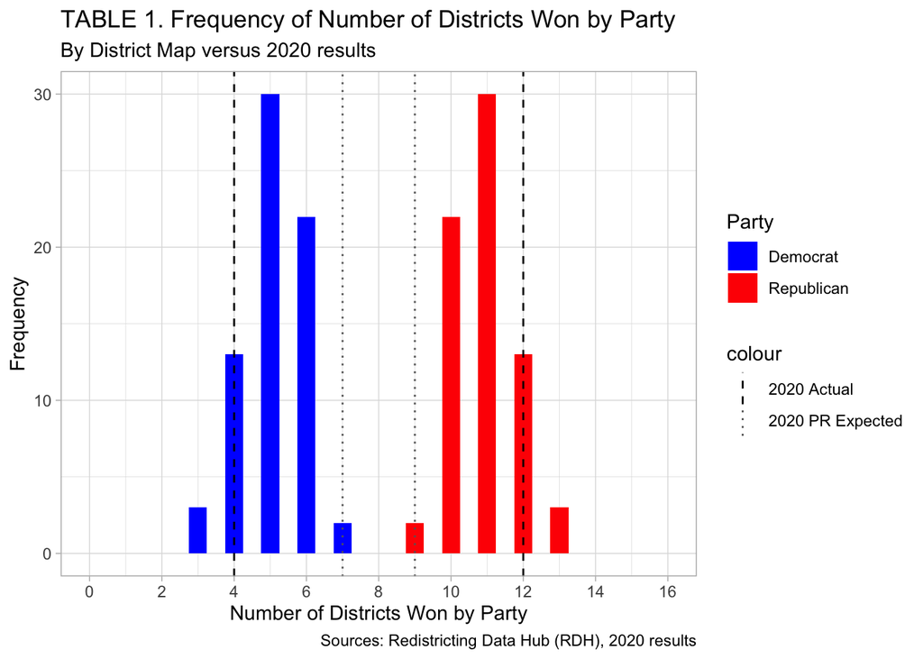

The procedurally generated maps rarely (3% of runs) created maps with the same seat allocation as the PR seat distribution. Maps with the same distribution as the actual 117th Congressional allocation of seats was more common (19% of runs) and several maps saw more extreme results still (4% of runs). A majority of runs produced seat allocation between the two comparison metrics (74% of runs).

#### District Competitiveness

**Absolute Win Margin.** The median absolute win margin across the 70 runs was 19.3% points, indicating the a two-party election result of 59.7% to 40.3%. The procedurally generated maps produced districts with the lowest absolute win margin from 0.1% points to 9.7% points, with a median most competitive district of 1.3% points. Additionally, they produced districts with the lowest absolute win margin from 29.6% points to 60.1% points, with a median least competitive district of 45.8% points.

The 2020 congressional election results saw district win margins ranging from 7.4% points to 60.1% points, with a median absolute win margin of 26.6% points.

Table 2 shows summary statistics calculated for each run, with the 117th Congress’s results shown in red. For mean and median results, a higher value indicates the average district within that map of 16 districts is more partisan. For minimum results, a higher value indicates the least partisan district (i.e., the most competitive district) is more partisan (less competitive); for maximum results, a lower value indicates the most partisan district (i.e., the “safest” district) is less partisan (more competitive). Overall, lower values indicate higher electoral competitiveness.

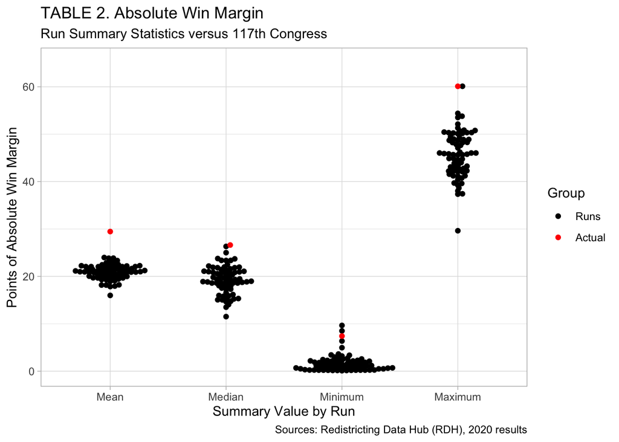

Across the procedurally generated maps, congressional districts were more competitive than the 117th Congress’s districts. All had the average district as more competitive than the actual districts used for the 117th Congress. A substantial majority (97.1%) had the most-competitive district as more competitive than the actual most competitive district in the 2020 election - Ohio’s 1st District. 95.7% of the maps produced at least one district with the absolute margin less than 5% points.

Of particular note here is the relatively high partisan leanings of the actual congressional districts. The 2020 election saw Ohio’s 1st District candidate Steve Chabot (R) win by 7.4% points. Indeed, in the Cook Political Report’s final 2020 House Race Ratings, only three of Ohio’s races were even listed as competitive - with two races the 10th District and 12th District rated as “Likely Republican;” OH-01 was listed as a toss-up.[^6] Democrats won the majority of seats in the House of Representatives in 2020 and Joe Biden won the presidential election, with the national electoral environment favoring the Democrats.

**Relative Win Margin.** Across the 70 runs, the median relative win margin was -10.4% points, or 10% points favoring Republicans.

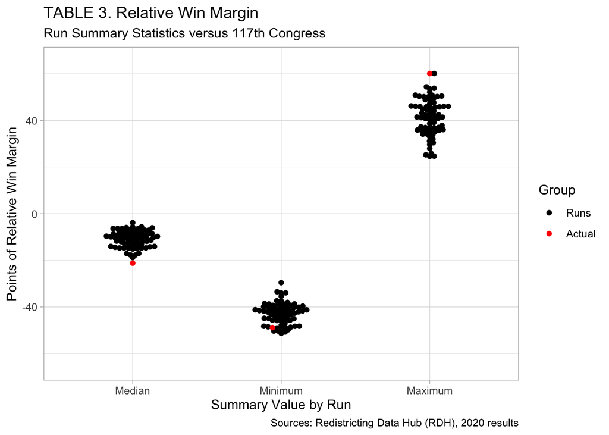

### Population

Congressional districts within each state are required to have equal populations, though the degree of their margin of error varies by state. Ultimately, districts will have small deviations above or below the target amount due to compiling geographic units of various populations. Ohio’s Constitution, as updated in 2021, stipulates that “[i]n no event shall any district contain a population of less than ninety-five per cent nor more than one hundred five per cent of the applicable ratio of representation” (Article XI, Section 3(B)(1)).[^7] This allows districts to have a population range of 10% of the target district population as measured by the decennial census, which based on the 2010 Census would be 72,103 individuals.

The algorithm for the procedurally generated maps had equal population levels baked in, resulting in populations falling well within the legally required ±5% of the distributed population $P_{16}$ = 721,032 (684,980 to 757,083 individuals). Across the 70 procedurally generated maps, the district with the smallest population had 714,681 individuals (99.1% of $P_{16}$), while the largest population had 726,986 individuals (100.8% of $P_{16}$). On average, the smallest and largest populations were 716,736 (99.4% of $P_{16}$) and 725,164 (100.6% of $P_{16}$). All values are within ±1% of $P_{16}$.

For Ohio’s redrawing following the 2010 Census, each district was expected to have approximately 721,032 individuals across its now 16 congressional districts. Using the same 2010 Census data, Ohio’s districts in the 113th Congress ranged from 721,031 individuals (100% of the target population) to 721,032 individuals (100%).

Table 4 shows the smallest and largest districts by population for each of the 70 procedurally generated maps as percentages of $P_{16}$. The smallest and largest district populations for the 117th congress are also shown.

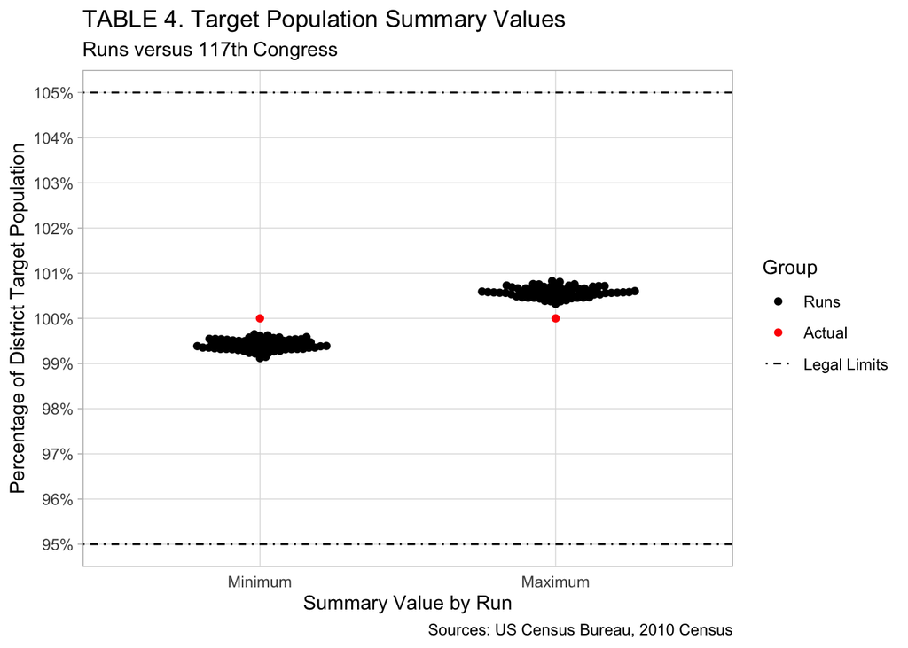

### Race/Ethnicity

States are forbidden from use race or ethnicity to politically disadvantage one or more particular groups. However, several states require the creation of one or more majority-minority districts, that is, a district with a larger proportion of Hispanic and non-White individuals than non-Hispanic White individuals. With the strong (though decreasing) correlation between race/ethnicity and voting patterns, separating redistricting based on demographic and partisan characteristics is challenging.

Overall, Ohio’s population according to the 2010 Census was 81.13% White, 12.04% Black, 3.07% Hispanic, 1.65% Asian, 0.18% American Indian or Alaskan Native (AIAN), 0.03% Native Hawaiian or Pacific Islander (NHPI), 0.13% other race, and 1.76% individuals identifying as two or more races. (Note Hispanic includes all individuals identifying as Hispanic regardless of racial identification. All race categories are for non-Hispanic individuals.) The proportion of individuals identifying as non-White in Ohio is 18.87%.

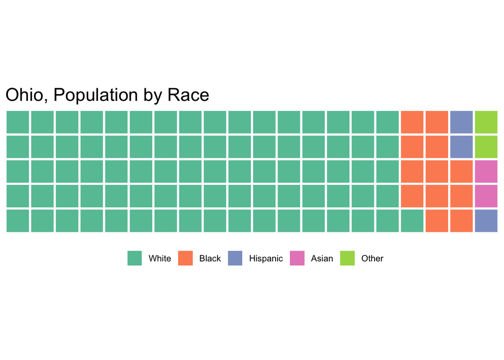

Looking at the minimum and maximum Diversity Index scores by map, lower minimum values and higher maximum values are a potential indication of packing or cracking racial groups. This may be done unintentionally, it may be unavoidable due to the distribution of racial and ethnic groups, or it may be done intentionally in the case of majority-minority districts.

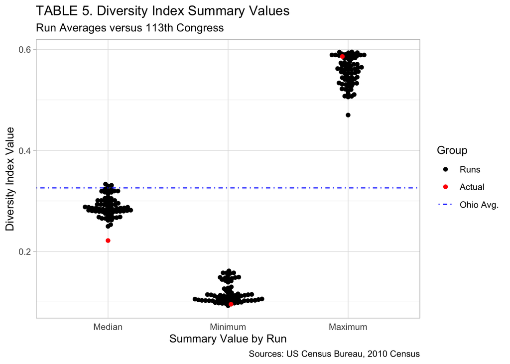

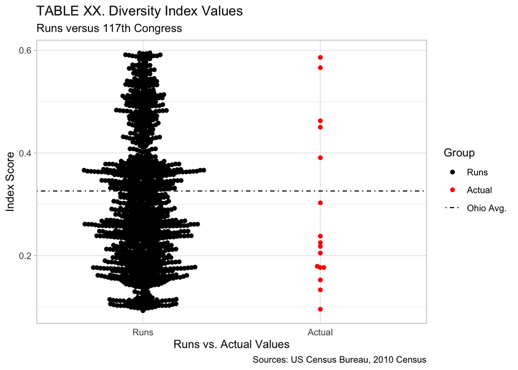

Another prominent measurement of racial/ethnic distribution is calculating the difference in the proportion of non-Hispanic White individuals versus non-White individuals.

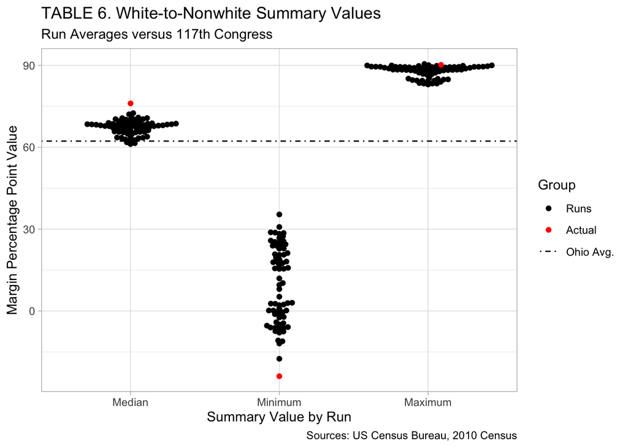

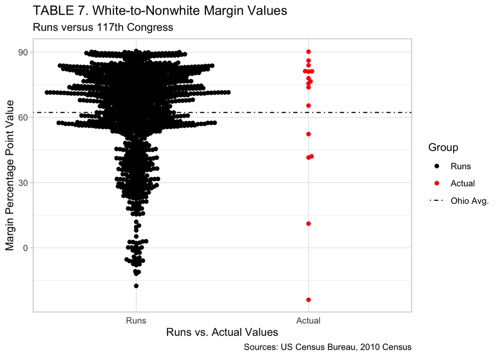

### District Compactness

Congressional districts in Ohio for the 117th Congress had several low-compact districts, notably the 9th, 11th, and 13th Districts. Of note, all three of these districts were won by Democrats in 2020. Ohio’s 5th congressional district was the most compact across all three measurements.

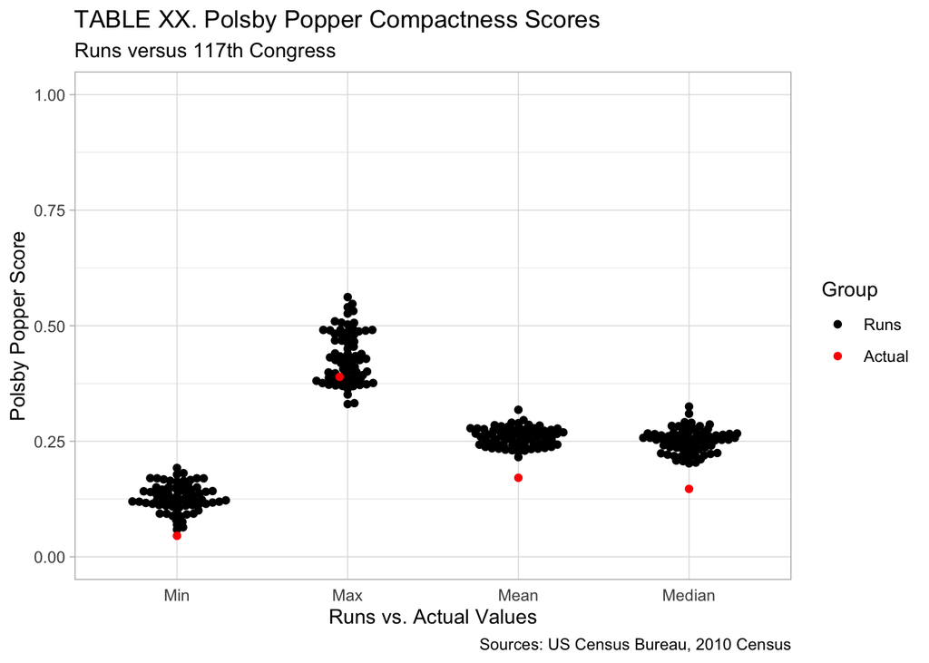

Across the procedurally generated maps, 18 runs (26%) had their least compact district as more compact than the median district from the 2020 election.

**Schwartzberg.**

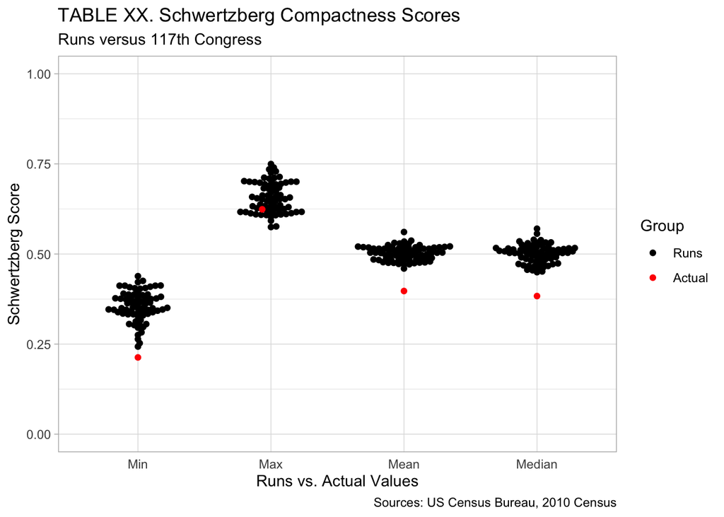

**Reock.**

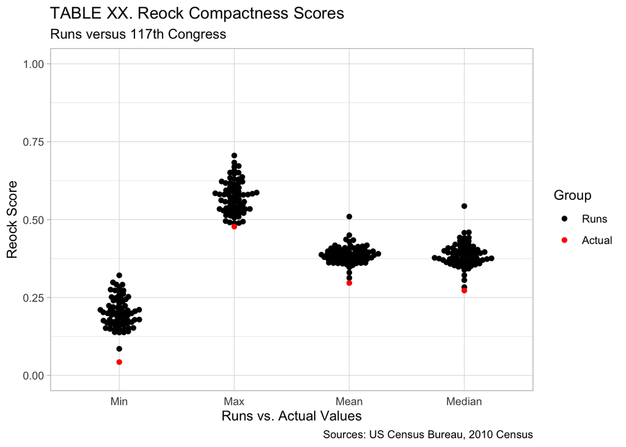

[^1]: “A Bellwether Refresher: The States Most Likely To Mirror National Election Outcome” by Ron Elving, NPR. https://www.npr.org/2016/11/06/500898858/a-bellwether-refresher-the-states-most-likely-to-mirror-national-election-outcom
[^2]: https://www.congress.gov/crs-product/R45951
[^3]: Voting Rights Act, SEC. 2. https://www.archives.gov/milestone-documents/voting-rights-act
[^4]: https://www.cincinnati.com/story/news/politics/2018/02/06/everyone-complains-gerrymandering-ohio-just-did-something/310438002/
[^5]: “Racial and Ethnic Diversity in the United States: 2010 Census and 2020 Census”, United States Census Bureau. https://www.census.gov/library/visualizations/interactive/racial-and-ethnic-diversity-in-the-united-states-2010-and-2020-census.html
[^6]: “2020 House Race Ratings” by the Cook Political Report, 2 November 2020 version. Accessible via WayBack Machine https://web.archive.org/web/20201104131118/https://cookpolitical.com/ratings/house-race-ratings
[^7]: Ohio Constitution Article XI, Section 3: https://codes.ohio.gov/ohio-constitution/section-11.3